# Tutorial 3

Zayd

24/01/2022

## Swiss Fertility Data

```r
data_swiss = read.csv("/Users/zaydomar/math_204_w22/Tutorials/Tutorial 3/swiss.csv")

fertility = data_swiss$Fertility
education = data_swiss$Education
n = length(fertility)
```

## Model Fitting

As always plot the data and do a quick visual exploration.

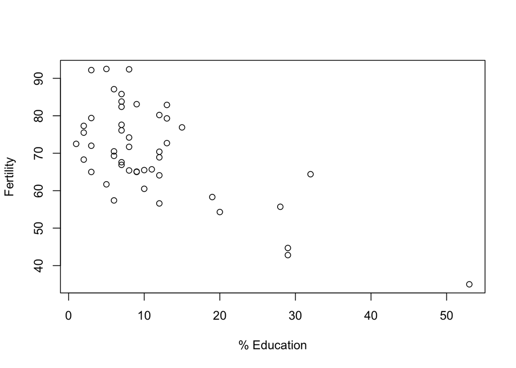

[output not shown]

```r
plot(education, fertility, xlab = "% Education", ylab = "Fertility")
```

## Hypothesis Test

To do the hypothesis test we first calculate the test-statistic. Which is given by,
$$T = \frac{\hat{\beta}-0}{\hat{\sigma}_{\hat{\beta}}} = \frac{-0.8624}{0.1448}=-5.954.$$

This is a statistic that we have to be able to calculate by hand, however, notice, if we are ``allowed" to use the summary function then we can also get the exact same summary statistic. The rejection region is given by, the following code or can be obtained from the t-table. Remember that in this case we have a two sided test so we need to find the upper and lower rejection region and then see whether or not the test-statistic lies in side the region or not.

```r
RR_upper = qt(p = 0.975, df = n-2)
RR_lower = qt(p = 0.025, df = n-2)

# qnorm(p = 0.975)    # Normal dist upper region
# qnorm(p = 0.025)    # Normal dist lower region

# The rejection region is given by,
RR_lower
```

```
## [1] -2.014103
```

```r
RR_upper
```

```
## [1] 2.014103
```

Our statistic clearly lies beyond the region and hence we reject the null hypothesis.

## Confidence interval

```r
confint(fit,level = 0.99)
```

```
##                 0.5 %     99.5 %
## (Intercept) 73.950910 85.2692066
## education   -1.251922 -0.4727781
```

## Correlation

The $r$ and $r^2$ can be computed by hand or using the $\mathtt{summary()}$ function. Note that the function only provides the coefficient of determination, i.e $r^2$ and we can use this to obtain the value of $r$.

```r
summary(fit)
```

```
##
## Call:
## lm(formula = fertility ~ education)
##
## Residuals:
##     Min      1Q  Median      3Q     Max
## -17.036  -6.711  -1.011   9.526  19.689
##
## Coefficients:
##             Estimate Std. Error t value Pr(>|t|)
## (Intercept)  79.6101     2.1041  37.836  < 2e-16 ***
## education    -0.8624     0.1448  -5.954 3.66e-07 ***
## ---
## Signif. codes:  0 '***' 0.001 '**' 0.01 '*' 0.05 '.' 0.1 ' ' 1
##
## Residual standard error: 9.446 on 45 degrees of freedom
## Multiple R-squared:  0.4406, Adjusted R-squared:  0.4282
## F-statistic: 35.45 on 1 and 45 DF,  p-value: 3.659e-07
```

$r^2=0.4406$, implying that about $44\%$ of the variation in $Fertility$ is explained by the $Education$ variable. At the same time the correlation is given $r = \sqrt{r^2}$. But what is the correct sign of $r$? Do we have a positive correlation or a negative correlation? It is easy to find this out by looking at what is the sign in front of $\hat{\beta}_1$. In this case it is a negative sign and so we have negative correlation.

## Fitted Line

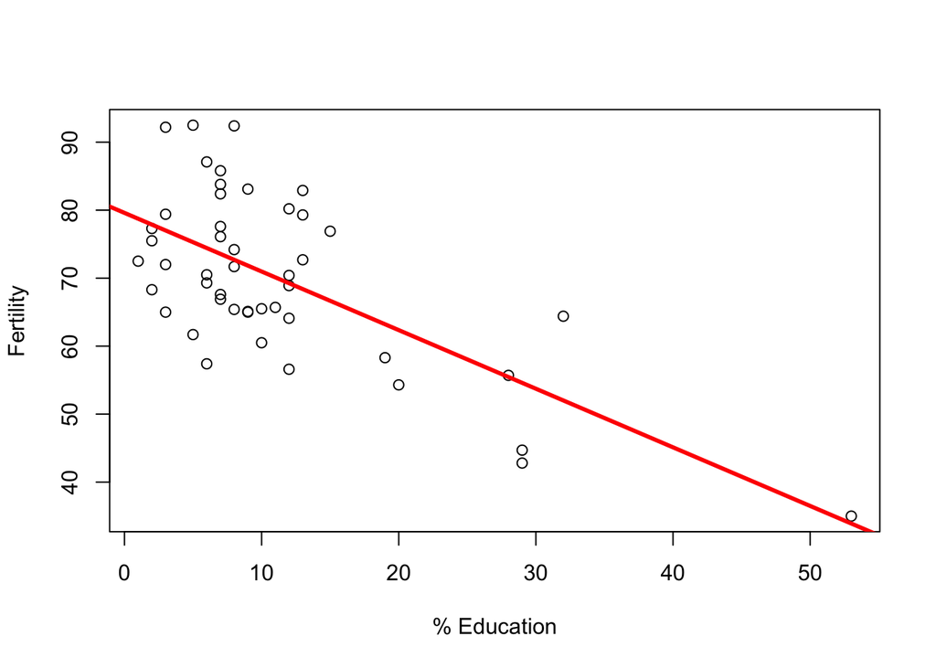

```r
plot(education, fertility, xlab = "% Education", ylab = "Fertility")
abline(a=fit$coefficients[1],b=fit$coefficients[2],col="red",lwd=3)
```

## Confidence Interval and Prediction Inveral

For $Education = 15$ we have the estimate for the mean response is $\hat{y} = 79.61-(0.8624)(15) = 66.674$. The confidence interval is given by,

$$\hat{y}\pm t^{n-2}_{\alpha/2}\times\hat{\sigma}\times\sqrt{\frac{1}{n}+\frac{(x_p-\bar{x})^2}{SS_{xx}}}.$$

The prediction interval is given by,

$$\hat{y}\pm t^{n-2}_{\alpha/2}\times\hat{\sigma}\times\sqrt{1+\frac{1}{n}+\frac{(x_p-\bar{x})^2}{SS_{xx}}}$$

```r
mean_edu = mean(education)

SSxx = sum((education-mean_edu)^2)
simga_hat = summary(fit)$sigma
# predicted value

y_hat=predict(fit,newdata = data.frame(education=15))
y_hat
```

```
##       1
## 66.6748
```

```r
# Confidence Interval
y_hat-2.014*simga_hat*sqrt(1/n+((15-mean_edu)^2)/SSxx)  # lower limit
```

```
##        1
## 63.66206
```

```r
y_hat+2.014*simga_hat*sqrt(1/n+((15-mean_edu)^2)/SSxx)  # upper limit
```

```
##        1
## 69.68755
```

```r
# Prediction Interval
y_hat-2.014*simga_hat*sqrt(1+1/n+((15-mean_edu)^2)/SSxx)  # lower limit
```

```
##        1
## 47.41343
```

```r
y_hat+2.014*simga_hat*sqrt(1+1/n+((15-mean_edu)^2)/SSxx)  # upper limit
```

```
##        1
## 85.93618
```

```r
## Or using the predict function we have that
predict(fit,newdata = data.frame(education=15),interval = "confidence")
```

```
##       fit      lwr     upr
## 1 66.6748 63.66191 69.6877
```

```r
predict(fit,newdata = data.frame(education=15),interval = "prediction")
```

```
##       fit      lwr      upr
## 1 66.6748 47.41244 85.93717
```

The CI and the PI look like this on the graph.

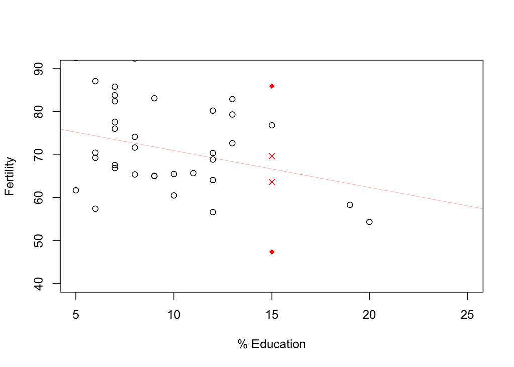

```r
plot(education, fertility, xlab = "% Education", ylab = "Fertility", xlim = c(5,25),ylim=c(40,90))
abline(a=fit$coefficients[1],b=fit$coefficients[2],col="red",lwd=0.2)
points(c(15,15),c(63.66,69.69), pch = 4, col = "red")
points(c(15,15),c(47.41,85.94), pch = 18, col = "red", lwd = 0.2)
```

## Subsetting the Data

This is an extra section. In this section I do some data subsetting using the snow-geese data set. I do th same thing using a few different functions so that you can choose any one you want to try, there is no one way to get the correct answer.

```r
data_geese = read.csv("/Users/zaydomar/Dropbox/Zayd/Class_Notes/MATH 204 Principles of Statistics/Asn2/SNOWGEESE.csv")

# See the following three ways to subset the data


## OPTION1: Using the dplyr library
data_subset1 = filter(data_geese,Diet != "Chow")

## OPTION2: Using Base R
data_subset2 = data_geese[data_geese$Diet != "Chow", ]

## OPTION3: Using Base R
data_subset3 = subset(data_geese, Diet != "Chow")
```

Test the datasets and you will see that they will all give you the same result. Remember, to use the $\mathtt{filter()}$ from $dplyr$, you **NEED** to have installed and attached the $dplyr$ library. If you are not able to install this, you can use the other two functions provided.